# Lab 5 Insurance Costs

```python
#import packages
import pandas as pd
from plotnine import *
from sklearn.model_selection import train_test_split
from sklearn.linear_model import LinearRegression
from sklearn.preprocessing import OneHotEncoder
from sklearn.pipeline import Pipeline
from sklearn.metrics import r2_score
from sklearn.compose import ColumnTransformer
from sklearn.metrics import mean_squared_error
from sklearn.preprocessing import PolynomialFeatures
import statsmodels.api as sm
import numpy as np
```

# Part 1: Data Exploration

```python
insurance = pd.read_csv("https://www.dropbox.com/s/bocjjyo1ehr5auz/insurance_costs_1.csv?dl=1")
insurance
```

|  | age | sex | bmi | smoker | region | charges |
| --- | --- | --- | --- | --- | --- | --- |
| 0 | 19 | female | 27.900 | yes | southwest | 16884.92400 |
| 1 | 33 | male | 22.705 | no | northwest | 21984.47061 |
| 2 | 32 | male | 28.880 | no | northwest | 3866.85520 |
| 3 | 31 | female | 25.740 | no | southeast | 3756.62160 |
| 4 | 60 | female | 25.840 | no | northwest | 28923.13692 |
| ... | ... | ... | ... | ... | ... | ... |
| 426 | 23 | female | 33.400 | no | southwest | 10795.93733 |
| 427 | 18 | female | 31.920 | no | northeast | 2205.98080 |
| 428 | 18 | female | 36.850 | no | southeast | 1629.83350 |
| 429 | 21 | female | 25.800 | no | southwest | 2007.94500 |
| 430 | 61 | female | 29.070 | yes | northwest | 29141.36030 |

431 rows × 6 columns

```python
#check data types for each column
insurance.dtypes
```

```
age          int64
sex         object
bmi        float64
smoker      object
region      object
charges    float64
dtype: object
```

```python
#count how many males and females
insurance["sex"].value_counts()
```

```
female    225
male      206
Name: sex, dtype: int64
```

```python
#average insurance charges based on sex
insurance[["sex", "charges"]].groupby("sex").mean()
```

| sex | charges |
| --- | --- |
| female | 11919.373162 |
| male | 12709.661784 |

On average, men are charged more for insurance than women.

```python
#average insurance charges based on smoker
insurance[["smoker", "charges"]].groupby("smoker").mean()
```

| smoker | charges |
| --- | --- |
| no | 7528.467642 |
| yes | 31152.372644 |

Smokers are billed more for insurance than for non-smokers.

```python
#average insurance charges based on region
insurance[["region", "charges"]].groupby("region").mean().sort_values(by = "charges", ascending = False)
```

| region | charges |
| --- | --- |
| southeast | 13916.786760 |
| northeast | 11985.217747 |
| southwest | 11765.159818 |
| northwest | 11097.220696 |

People living in the southeast region are billed the most in medical costs by health insurances. People living in the northwest region are billed the least in medical costs.

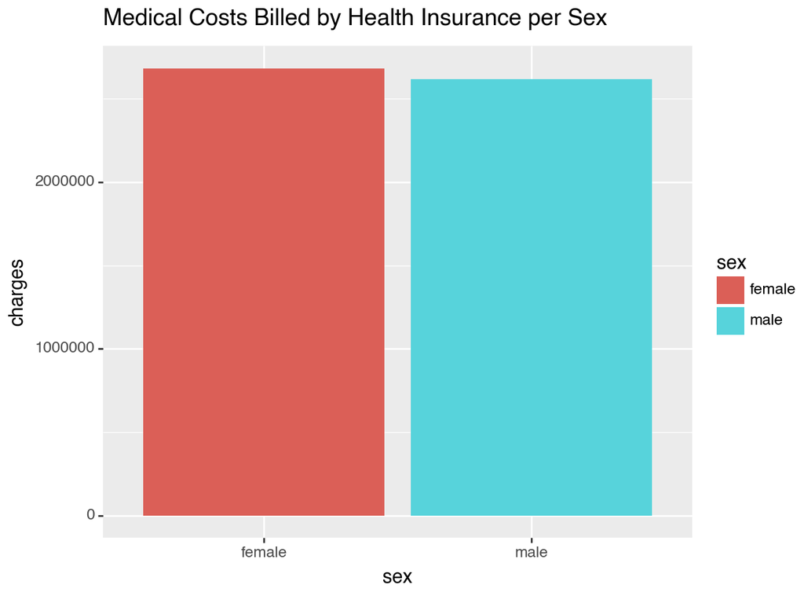

```
<Figure Size: (640 x 480)>
```

```python
#plot 1: sex v/s charges
(ggplot(insurance, aes(x = "sex", y = "charges", fill = "sex"))
 + geom_col()
 + ggtitle("Medical Costs Billed by Health Insurance per Sex")
)
```

From this graph, we can say that females pay slightly more in medical bills than males. However, we also must keep in mind that there are more females than males in the data set.

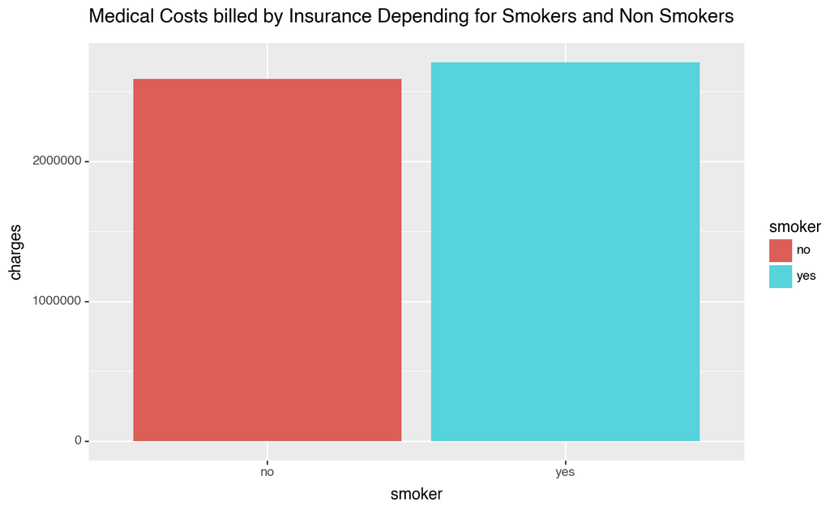

```
<Figure Size: (800 x 500)>
```

```python
#plot 2: smoker v/s charges
(ggplot(insurance, aes(x = "smoker", y = "charges", fill = "smoker"))
 + geom_col()
 + ggtitle("Medical Costs billed by Insurance Depending for Smokers and Non Smokers")
 + theme(figure_size = (8, 5))
)
```

This plot shows that smokers pay more in medical costs billed by insurances than nonsmokers. This matches the summary statistic created above.

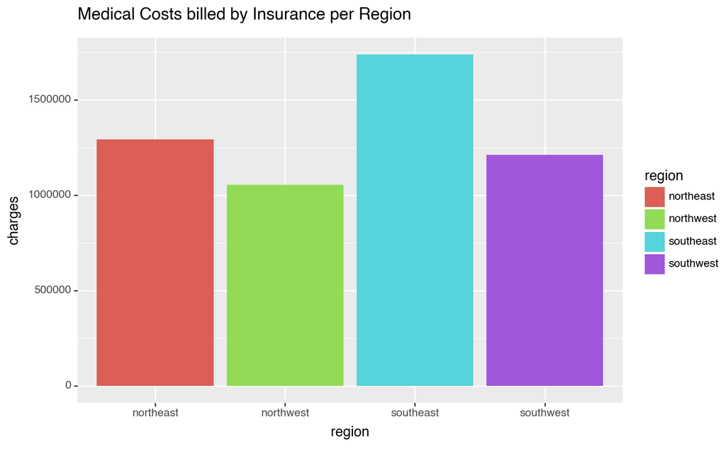

```
<Figure Size: (800 x 500)>
```

```python
#plot 3: region v/s charges
(ggplot(insurance, aes(x = "region", y = "charges", fill = "region"))
 + geom_col()
 + ggtitle("Medical Costs billed by Insurance per Region")
 + theme(figure_size = (8, 5))
)
```

This plot shows that the southeast region pays the most in medical costs billed by insurances. This matches the summary statistic created above.

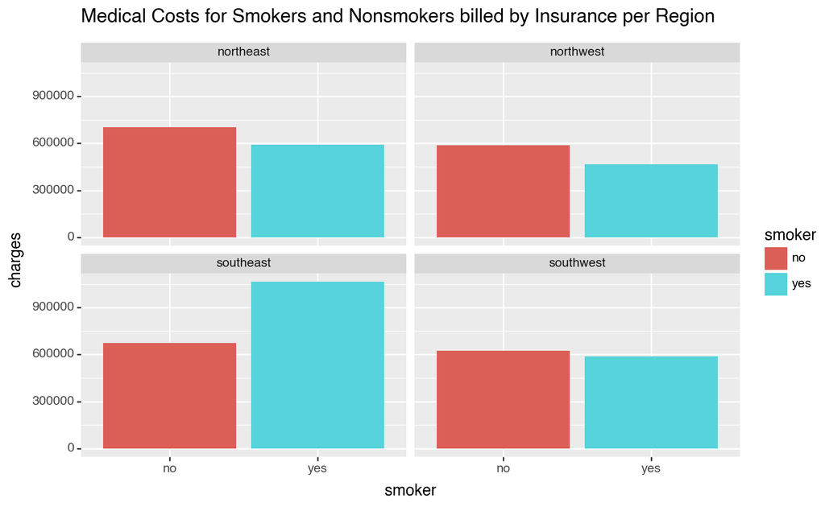

```
<Figure Size: (800 x 500)>
```

```python
#plot showing region and smoking
(ggplot(insurance, aes(x = "smoker", y = "charges", fill = "smoker"))
 + geom_col()
 + ggtitle("Medical Costs for Smokers and Nonsmokers billed by Insurance per Region")
 + theme(figure_size = (8, 5))
 + facet_wrap("region")
)
```

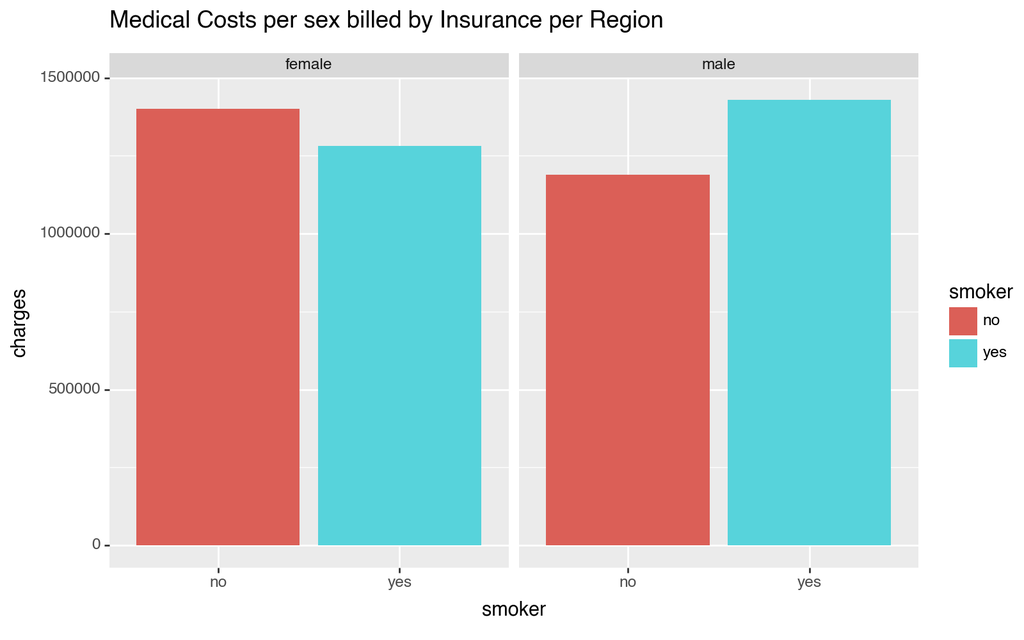

```
<Figure Size: (800 x 500)>
```

```python
(ggplot(insurance, aes(x = "smoker", y = "charges", fill = "smoker"))
 + geom_col()
 + ggtitle("Medical Costs per sex billed by Insurance per Region")
 + theme(figure_size = (8, 5))
 + facet_wrap("sex")
)
```